# Lab 5: One-Sample t-Test

Authors

Yeon Soon Shin

Anjali Thapar

Dustin Albert

Kevin P. McIntyre

# 1 One-sample t-test

> This lab is adapted from Kevin P. McIntyre’s [OSL Open Stats Lab](https://sites.google.com/view/openstatslab/home/regression-activities?pli=1&authuser=0).

In this lab, we will conduct our first statistical test. Exciting!

Today’s data comes from Tworek and Cimpian (2016). Tworek and Cimpian (2016) investigated what predicts people’s tendency to think what “is” is what “ought to be”. They hypothesized that this tendency is related to people’s preference for explanations that are based on inherent properties (e.g., “Pink is the color associated with girls because of something about the color pink or about girls— maybe because pink’s flower-like appearance matches girls’ dainty nature”) versus extrinsic properties (e.g., “Pink is the color associated with girls because of some historical or contextual reason—maybe because businesses promoted pink products for girls over the last century.”)–called “inherence bias”.

For this lab, we will explore whether there is a significant inherence bias in the population, first answering a single-variable question: what is the state of the inherence bias in the population?

In their first study, Tworek and Cimpian (2016) recruited a sample of 122 adults on an online platform called Amazon Mechanical Turk. Inherence bias was measured using 15 items that asked participants to rate their agreement with inherence-based explanations on a 9-point scale (1 = disagree strongly, 9 = agree strongly). For example, participants were presented with a statement like “Pink is the color associated with girls because of something about the color pink or about girls— maybe because pink’s flower-like appearance matches girls’ dainty nature” and asked to rate their agreement with that statement on a 9-point scale. The composite score is the average of the 15 items. We want to test whether the average inherence bias score in the population is different from 5, which is the midpoint of the scale.

One-sample t-tests are perfect for this type of question – we have a single variable that we want to test against some baseline value, and we do not know the population standard deviation.

## 1.1 Null Hypothesis and Alternative Hypothesis

The null hypothesis is that the average inherence bias score in the population is equal to 5. The alternative hypothesis is that the average inherence bias score in the population is not equal to 5. Because the average inherence bias could be either higher than 5 (indicating that there is indeed an inherence bias in the population) or lower than 5 (indicating that people have bias in the opposite direction and find explanations in the extrinsic properties), we will conduct a two-sided test.

*H*<sub>0</sub> : *μ* = 5 *H*<sub>1</sub> : *μ* ≠ 5

## 1.2 Preliminaries

```r
library(tidyverse)  # for data wrangling and visualization
library(psych)      # for describe() and scoreItems()
library(janitor)    # for frequency and contingency tables
library(broom)      # for tidy t-test output
library(papaja)     # for APA style output
library(lsr)        # for cohensD()
library(BrailleR)   # for accessibility
GoBlind()
```

## 1.3 Data

The data is in the `tworek2016_study1.csv` file in the `data` folder. There are two variables that are relevant for our analysis:

- `Inherence Bias`: The average score of the 15 items that measure inherence bias. This is our DV.
- `Excluded`: A variable that indicates whether the participant was excluded from the analysis. Participants were excluded if they failed attention checks or if they did not complete the survey. We will only include participants who were not excluded in our analysis.

**TipQuestions to answer about the data:**

- How many observations are in the dataset? Does it match the number of participants in the survey (N=122)?
- Are there any missing values in the dataset?
- Are all variables in the expected range?

### 1.3.1 Read in and clean the data

#### 1.3.1.1 Select the variables of interest

We can select these variables using the `select()` function from the `dplyr` package. The output of `select()` is a new data frame that contains only the variables we selected, and will be used for our analysis in `df`.

```r
df <- read_csv('data/tworek2016_study1.csv') %>%
  as_tibble() %>%
  select(`Inherence Bias`, Excluded)
```

**NoteBackticks around variable names when there are spaces**

Do you notice the backticks(`) around the variable name? This is because the variable name has a space in it, and R does not allow spaces in variable names. The backticks allow us to use variable names with spaces in them. It is a little inconvenient, and it is generally a good idea to avoid spaces in variable names.

#### 1.3.1.2 Inspect the variables as rows: `glimpse()` from `tidyverse`

```r
glimpse(df)
```

```
Rows: 131
Columns: 2
$ `Inherence Bias` <dbl> 7.666667, 7.333333, 5.333333, 5.800000, 4.266667, 5.2…
$ Excluded         <dbl> 0, 1, 0, 0, 0, 0, 0, 0, 0, 0, 0, 0, 1, 0, 0, 1, 0, 0,…
```

#### 1.3.1.3 Remove excluded participants

There are 131 observations in this dataset, but we know some particpants were excluded from the analysis. Let’s check how many participants were excluded.

```r
df %>%
  tabyl(Excluded) %>%
  adorn_totals("row") %>%
  adorn_pct_formatting(digits = 2) %>%
  knitr::kable()
```

| Excluded | n | percent |
| --- | --- | --- |
| 0 | 122 | 93.13% |
| 1 | 9 | 6.87% |
| Total | 131 | 100.00% |

Excluded participants are marked with 1 in the `Excluded` variable. We can filter out these participants using the `filter()` function from the `dplyr` package. The output of `filter()` is a new data frame that contains only the rows that meet the condition we specified, and will be used for our analysis in `df`.

```r
df <- df %>%
  filter(Excluded == 0)
```

Now check the number of observations in the dataset again. It should be 122.

```r
glimpse(df)
```

```
Rows: 122
Columns: 2
$ `Inherence Bias` <dbl> 7.666667, 5.333333, 5.800000, 4.266667, 5.266667, 6.6…
$ Excluded         <dbl> 0, 0, 0, 0, 0, 0, 0, 0, 0, 0, 0, 0, 0, 0, 0, 0, 0, 0,…
```

### 1.3.2 Inspect the Data

#### 1.3.2.1 Summary Statistics: `describe()` from the `psych` package

```r
describe(df) %>%
  knitr::kable()
```

|  | vars | n | mean | sd | median | trimmed | mad | min | max | range | skew | kurtosis | se |
| --- | --- | --- | --- | --- | --- | --- | --- | --- | --- | --- | --- | --- | --- |
| Inherence Bias | 1 | 122 | 5.911475 | 1.148207 | 5.9 | 5.90068 | 1.03782 | 1.8 | 8.933333 | 7.133333 | -0.118132 | 0.9553329 | 0.1039538 |
| Excluded | 2 | 122 | 0.000000 | 0.000000 | 0.0 | 0.00000 | 0.00000 | 0.0 | 0.000000 | 0.000000 | NaN | NaN | 0.0000000 |

## 1.4 Check Assumptions

There are three assumptions for a one-sample t-test. Two of those are more about the design: (1) the data are continuous (interval or ratio scale) and (2) the data are independent – no same participant is measured more than once in our sample. The data is indeed continuous, because it is the average of 15 items that are measured on a 9-point scale. We will assume that the authors took care to ensure that the data are independent.

### 1.4.1 Normality

The third assumption is about the distribution of the data: (3) the data are normally distributed. t-test is robust to moderate violations of normality, but we will still check the distribution of the data using a histogram and the Shapiro-Wilk test.

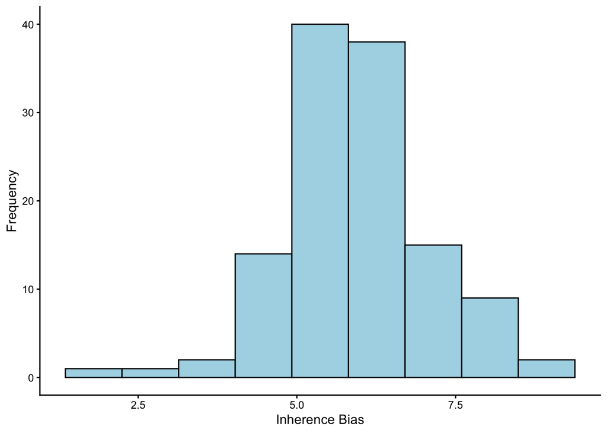

```
This is an untitled chart with no subtitle or caption.
It has x-axis 'Inherence Bias' with labels 2.5, 5.0 and 7.5.
It has y-axis 'Frequency' with labels 0, 10, 20, 30 and 40.
The chart is a bar chart with 9 vertical bars.
Bar 1 is centered at 1.8, and length is from 0 to 1.
Bar 2 is centered at 2.69, and length is from 0 to 1.
Bar 3 is centered at 3.58, and length is from 0 to 2.
Bar 4 is centered at 4.47, and length is from 0 to 14.
Bar 5 is centered at 5.37, and length is from 0 to 40.
Bar 6 is centered at 6.26, and length is from 0 to 38.
Bar 7 is centered at 7.15, and length is from 0 to 15.
Bar 8 is centered at 8.04, and length is from 0 to 9.
Bar 9 is centered at 8.93, and length is from 0 to 2.
It has colour set to black.
It has fill set to very light greenish blue.
```

```r
df %>%
    ggplot(aes(x = `Inherence Bias`)) +
    geom_histogram(bins = 9, color = "black", fill = "lightblue") +
    labs(x = "Inherence Bias", y = "Frequency") +
    theme_classic()
```

#### 1.4.1.1 Shapiro-Wilk Test: `shapiro.test()` from base R

There is a statistical test for normality called the Shapiro-Wilk test. The null hypothesis for the Shapiro-Wilk test is that the data are normally distributed. If the p-value is less than 0.05, we reject the null hypothesis and conclude that the data are not normally distributed. So here, what we are looking for is that “there is not enough evidence that the data are not normally distributed” – when p > .05, we proceed with the test.

**CautionHelp! My Shapiro-Wilk Test p-value is less than 0.05!**

You can breathe. t-test is robust to moderate violations of normality, and the Shapiro-Wilk test is very sensitive when the sample size is large. When the sample size is large, even small deviations from normality can lead to a significant result. Therefore, it is important to also look at the histogram of the data to see if the distribution is approximately normal. Even if the p-value is less than .05, if your histogram is not too skewed or too heavy-tailed, you can still proceed with the t-test.

If your sample size is small and the p-value is less than .05, you may want to consider using a non-parametric test instead of the t-test. Non-parametric tests do not assume normality, but they are less powerful than parametric tests.

A non-parametric alternative to the one-sample t-test is the Wilcoxon signed-rank test – instead of testing hypotheses about the mean, it tests hypotheses about the median (hence, the “rank”). You can use the `wilcox.test()` function from base R to conduct the Wilcoxon signed-rank test.

```r
shapiro.test(df$`Inherence Bias`)
```

```
    Shapiro-Wilk normality test

data:  df$`Inherence Bias`
W = 0.98393, p-value = 0.1566
```

There is no evidence that the data are not normally distributed, so the assumption of normality is met, and we are good to go with the t-test.

## 1.5 One-Sample t-Test

To compute the one-sample t-test, we will use the `t.test()` function from base R. The first argument is the variable we want to test, the second argument `mu` is the hypothesized population mean (5 in this case), and the third argument `alternative` is the alternative hypothesis (“two.sided” for a two-tailed test).

```r
t.test(df$`Inherence Bias`,
        mu = 5,
        alternative = "two.sided")
```

```
    One Sample t-test

data:  df$`Inherence Bias`
t = 8.7681, df = 121, p-value = 1.367e-14
alternative hypothesis: true mean is not equal to 5
95 percent confidence interval:
 5.705671 6.117279
sample estimates:
mean of x
 5.911475
```

Let’s unpack the output.

In the first line, it reports the t statistic (test statistic t), the degrees of freedom (df), the p-value (p).

t distribution’s shape is determined by the degrees of freedom, so it is essential to report the degrees of freedom along with the t statistic and p-value.

> t(df) = t statistic, p = p-value

Because the p-value is very small, we can report it as p < .001.

> *t*(121) = 8.77, *p* < .001

If you just report this, however, you are depriving your readers of the information about what your sample estimate is, and how confident you can be about that estimate. The output also reports the sample mean (mean of x) and the 95% confidence interval for the population mean (95 percent confidence interval).

> M = sample mean, 95% CI [lower bound, upper bound]

In a sentence, it looks like this:

> The average inherence bias score was significantly higher than the baseline (5), *M* = 5.91, 95% CI $[5.71, 6.12]$, *t*(121) = 8.77, *p* < .001.

There is an easy way to print this in the APA style using the `apa_print()` function from the `papaja` package. The output is a list of character strings that can be printed in the manuscript.

The probability of observing sample means as extreme as the one we observed or more extreme, given the baseline value of 5, is less than 0.05. Therefore, we can reject the null hypothesis and conclude that the average inherence bias score in the population is significantly different from 5. Because the average is greater than 5, we can report that there is a significant inherence bias in the population.

```r
res_apa <- t.test(df$`Inherence Bias`,
        mu = 5,
        alternative = "two.sided") %>%
    papaja::apa_print()
res_apa$full_result
```

```
[1] "$M = 5.91$, 95\\% CI $[5.71, 6.12]$, $t(121) = 8.77$, $p < .001$"
```

You can print this in the Quarto document using the `` `r` `` inline code chunk.

`r res_apa$full_result`

*M* = 5.91, 95% CI $[5.71, 6.12]$, *t*(121) = 8.77, *p* < .001

### 1.5.1 Effect Size (Cohen’s d)

We will report the effect size using Cohen’s d. We can compute it using the `cohensD()` function from the `lsr` package. `mu` is the hypothesized population mean at the baseline (the midpoint of the scale).

```r
d <- cohensD(df$`Inherence Bias`, mu = 5)
d
```

```
[1] 0.7938249
```

## 1.6 Write up the results

> A one-sample t-test was performed to compare inherence bias score against the scale midpoint of 5. The results indicated that the mean inherence bias was significantly above the midpoint, *M* = 5.91, 95% CI $[5.71, 6.12]$, *t*(121) = 8.77, *p* < .001, with a moderate effect size, d = 0.79. These results suggest that people tend to endorse explanations that are based on inherent properties.

**TipOne-Sample t-Test Write-Up Checklist**

- What type of test was performed, to test what hypothesis?
- Which DV was tested, and what was the baseline value it was compared to?
- What was your estimate of the mean?
  - M
  - 95% CI
- What are the results of the analysis?
  - Was the mean significantly higher or lower than the baseline? In which direction?
  - t statistic
  - degrees of freedom
  - p-value
- What was the practical significance of the results?
  - Small, medium, or large effect size?
  - Cohen’s d
- What does the statistical result mean in the context of the research question?

You’ve completed a one-sample t-test! Woohoo!

## 1.7 Exercise 1

**TipStudy 2**

Do you find the results from Study 1 convincing? For one, what if people just have a general tendency to agree with any statement, regardless of whether it is based on inherent or extrinsic properties? To address this concern, Tworek and Cimpian (2016) conducted a second study.

This time, the inherence bias score was measured as a relative preference for inherent explanations over extrinsic explanations for the same 15 items. For example, participants were presented with a statement like “Pink is the color associated with girls because of something about the color pink or about girls— maybe because pink’s flower-like appearance matches girls’ dainty nature” and asked to rate their agreement with that statement on a 9-point scale. Then, they were presented with a statement like “Pink is the color associated with girls because of some historical or contextual reason—maybe because businesses promoted pink products for girls over the last century.” and asked to rate their agreement with that statement on a 9-point scale. The relative preference score is the difference between the two scores (inherent - extrinsic). This difference score is in `diff` variable in the dataset. The baseline value is 0, which indicates no preference for either type of explanation.

There are 139 participants in this study. 27 participants were excluded from the analysis (marked as 1 in the `excluded` variable), resulting in 112 participants in the final analysis.

**Repeat the one-sample t-test for study 2 in the `tworek2016_study2.csv` file.** Write up the results in APA style, interpreting the results in the context of the research question.

## 1.8 Bonus Exercises

If you want to practice your skills, try the following bonus exercises.

**TipBonus Exercise: Demographics Data and External Validity**

Whenever you conduct a study, it is important to report the demographics of your sample. The demographics data is in the `Age` and `Gender` variables in Study 1, and `age` and `gender` variables in Study 2.

Use the `tabyl()` function from the `janitor` package to create frequency tables for the demographics data. Do you find any interesting patterns in the demographics data? How might these patterns affect the generalizability of the results?

**TipBonus Exercise: Reliability Analysis**

They’ve used a 15-item scale to measure inherence bias. Using the reliability analysis we learned in lab 2, compute Cronbach’s alpha for the 15 items. Report the results in APA style, interpreting the results in the context of the research question.

In study 1, the variables start with `ih01`, `ih02`, …, `ih15` in the dataset. The two attention check items are `ihc1` and `ihc2`, so you should exclude them from the analysis. You can combine `starts_with()` within `select()` to select the 15 desired items. The `Excluded` variable is also in the dataset, so you should use that variable to filter out participants who are excluded from the analysis.

In study 2, the variables that are relevant for the reliability analysis are `ih01`, `ih02`, …, `ih15` and `ext01`, `ext02`, …, `ext15`. The two attention check items are `ihcatch1` and `ihcatch2`, so you should exclude them from the analysis. The average scores for each participant are in the `ihav` and `extav` variables, which should not be included in the reliability analysis, as they are already aggregated scores.

Because the ih and ext items are measuring the opposite constructs, you should reverse -code the ext items before computing Cronbach’s alpha.

For study 2, the `excluded` variable is also in the dataset, so you should filter out participants who are excluded from the analysis as well.

## References

Tworek, Christina M., and Andrei Cimpian. 2016. “Why Do People Tend to Infer ‘Ought’ From ‘Is’? The Role of Biases in Explanation.” *Psychological Science* 27 (8): 1109–22. https://doi.org/10.1177/0956797616650875.